[Rmd source](https://github.com/hrpunio/Bookdown/tree/main/Misc)

# Short overview of Information Technology

TP

2021-03-01

## The name of the Game

Bussiness and Science

Science: **Computer Science** (Math), **Information Systems** (Still math but engineering), **MIS** (Management); Artificial Intelligence; Datology (Peter Naur)

Peter Naur suggested the term **datalogy**, to reflect the fact that the scientific discipline revolves around data and data treatment (CS is about data processing ie algoritms mainly)

Bussiness: Programs (Hardware) + Procedures (Software) + (by)Product (Data) as any other branch farming for example

**Technology**: the application of scientific knowledge for practical purposes, especially in industry.

**Layers of IT**: computing, storage, communication (credits: https://www.amazon.com/Software-Ecosystem-Understanding-Indispensable-Technology/dp/0262633310 )

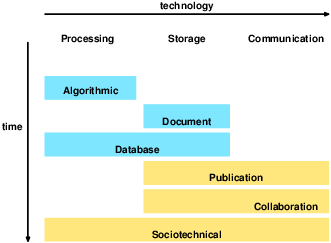

Applications (Software): licence model; open source; software as service (SaS)

https://www.youtube.com/watch?v=a8fHgx9mE5U (What is Open Source explained in LEGO)

**Embedded software** (is it an application?)

## Data

**Data representation** (binary vs structured or human comprehensible): Modern computers are digital machines (digital machines), i.e. processed data are represented as a string of binary values. This type of data has no obvious human interpretation:

010010111010101101010110 …

Representing information in a digital system means converting human-readable data into a sequence of bits (and vice-versa) A set of rules according to which it is made above the replacement is called a **data format** (or notation). Knowledge of the data format allows you to decode binary data into a human-readable form.

A **data structure** is the internal representation of data in a computer’s memory designed for their processing.

- Structures and formats (for the same data) are usually different (optimization).
- Serialization and deserialization (parsing, loading).

A **data model** is a formalized, logical data structure and (usually) ways manipulating them (e.g. modifying, searching etc …). An example of a model data is the **relational model** that is the basis of modern databases.

A **data schema** is a description of a data structure that conforms to a specific formal data model (ie instance of a model):

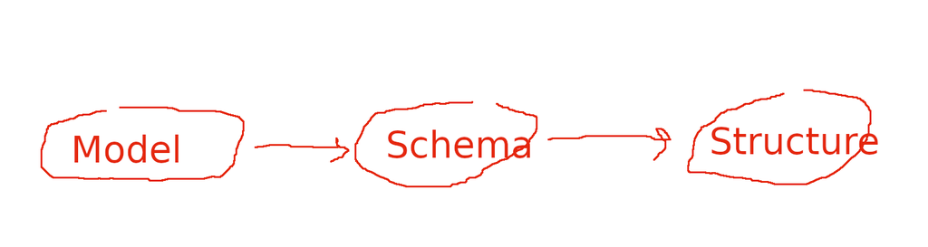

Data: **Proprietary** vs **Open** vs **(common) Standards**

Data: **structured** and **unstructured**. How structured? XML, Relational model, domain-specific models

**Metadata** or data about data (example EXIF data)

An information system (IS) is a model of a part of the world. **Formal** vs **informal systems**. The basis of the (formal) IS is the data model / schema used for data storage. The scheme determines the functionality of the system.

## Documents or semistructure data (XML)

A document is a self-contained unit of information, intended to be communicated to a human.

The data that is meant to be machine processable (fragmented) is not a document (example: database record)

Document = content + form

**Format a document** = to add graphical form to a content.

**markup** = intruction about formatting. (Change font size to 14pt is a markup)

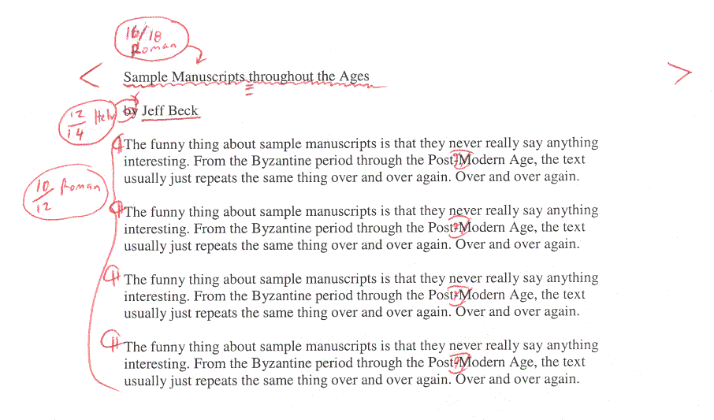

logical and visual markup.

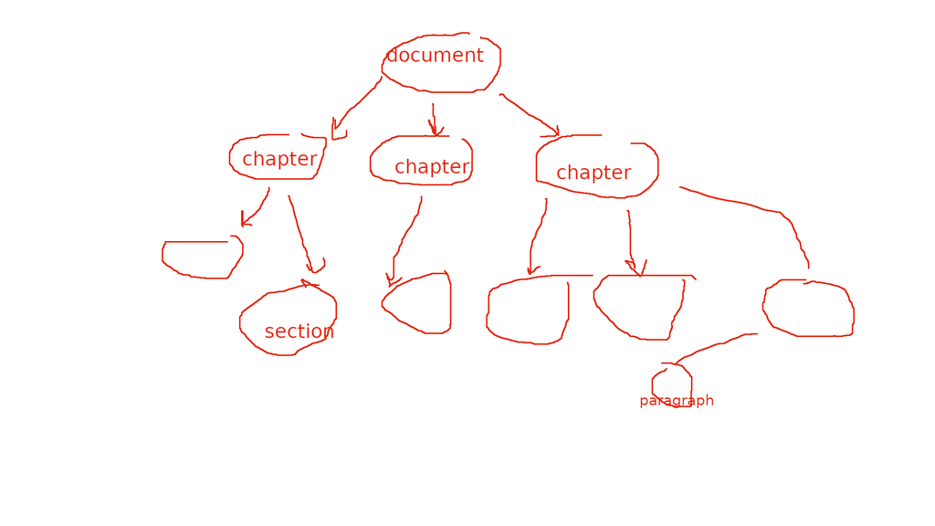

Mark-up based document processing examples: TeX and Markdown

## Databases or DBMS. SQL

Workhorses of modern IT applications

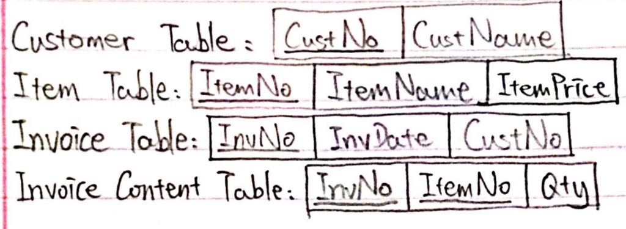

examples: mySQL or sqlite

## Domain specific

Fonts for example

## Software Applications

**Infrastructure**, **operating system**, middleware and user applications

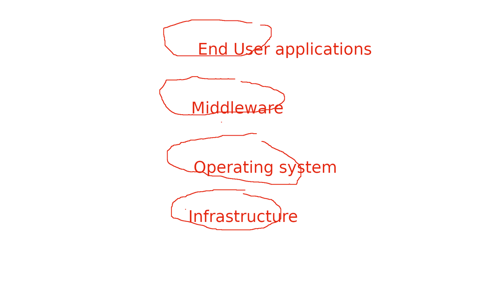

- End-user computing,
- cloud computing/SaaS

Licence (patents and copyrights) OSS license vs MS EULA

End-user applications example: **Office** computing (spreadsheet), publication (editor), presentation (PP)

Excel errors https://en.wikipedia.org/wiki/Growth_in_a_Time_of_Debt

While using RR’s working spreadsheet, we identified coding errors, selective exclusion of available data, and unconventional weighting of summary statistics

PP errors https://www.youtube.com/watch?v=j4JOjcDFtBE

Edward Tufte (and Shuttle Columbia disaster) https://lvlinguistics.be/death-by-powerpoint/ (google: Software that kills Tufte or Tufte powerpoint) https://www.inf.ed.ac.uk/teaching/courses/pi/2016_2017/phil/tufte-powerpoint.pdf (cf https://www.edwardtufte.com/tufte/powerpoint)

Operating system: Windows, Linux/Android, MacOS

IT systems evolution (from australopitek to humanerectus):

- transactional
- DSS (Decision Support Systems)/EIS (Executive IS)
- ERP (Enterprise Resources planning
- CRM (Consumer Relationship Management IS)

Open Source Software

Who develops applications? Almost everone but not everyone sells it. Application sellers: Microsoft, Oracle vs application providers (google)

IT doesnet matter (HBR/Carr https://hbr.org/2003/05/it-doesnt-matter)

Future of industry: WTF/O’Reilly https://www.oreilly.com/tim/wtf-book.html or https://www.oreilly.com/library/view/wtf-whats-the/9780062565723/

## Hardware

Not for us

## Economy of Software Industry

**Value chain** of sotware development: **production** (manufacturing/testing/documenting/assembling), **delivery** (sales/marketing),  
**commissioning** (consulting/integration/implementation/training) **use** (support/management).

Note: **packaging** = assembling software components into a **package** that provides certain functionality (https://en.wikipedia.org/wiki/Software_package)

Consequences: you can earn money of software not only by selling lincese fees

Technology: **proprietary** and **ifrastructural**. Infrastructural technology is **commoditized** (commoditized goods and services only differ in their prices from various providers, see also https://en.wikipedia.org/wiki/Commoditization)

One **can** gain market advantage on **differentiating technology** only. One cannot gain market advantage on commoditized technology.

Commodity stack vs market strategy for MS/Oracle/SAP/Google

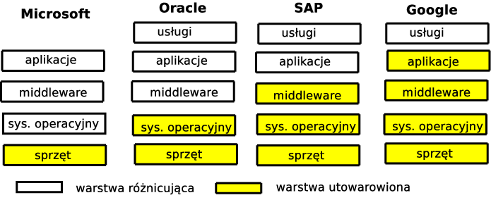

Consequences: for Google hardware (sprzęt), operating system (system operacyjny), middleware and applications should be as cheap as possible. Not so for Microsoft…

Software and **information good** in general has zero **marginal costs** and high **fixed costs**. Those fixed costs are mainly https://en.wikipedia.org/wiki/Sunk_cost

Economies of **scale** https://en.wikipedia.org/wiki/Economies_of_scale vs (higher volume is more profitable) economies of **scope** (greater variety is more profitable) https://en.wikipedia.org/wiki/Economies_of_scope With Info goods both EoScale/EoScope is easy to use (ie costless)

Consequences: **price** as equal to marginal costs of production as claimed in classical economy (https://www.britannica.com/topic/marginal-cost-pricing) is per definition impossible.

**Product life-cycle**:

- early-adoption-phase (small number of users/buyers; **unprofitability phase**)
- **critical-mass** point (a point when product/service becomes profitable)
- self-sustained-phase (the business is profitable)

https://xdedvukaj.medium.com/will-uber-ever-be-profitable-68ec2039da5e

Consequences: prohibitive barriers to entry for competitors (ie. Monopoly)

Uber case: https://hbr.org/2016/04/network-effects-arent-enough

**Network effect** (aka network externality) Microeconomic theory defines an **externality** or **spill-over** to be a situation in which the production or consumption activities of one individual or firm have an impact on the production or utility functions of other (not directly involved) economic agents, without this effect being accounted for via the price mechanism.

Compare: one buys a bigMac; one buys a car (possible both positive/negative externalities) one buys a smartphone

https://en.wikipedia.org/wiki/Network_effect

Consequences: the value of a software product/service increases as more users adopt the product without extra costs for already-users. More barriers for potential competitors…

Innovation platforms *consist of common technological building blocks that the owner and ecosystem partners can share in order to create new complementary products and services* (Cusumano et al. 2019, p. 18). Microsoft Windows, Google Android and Apple iOS are computer operating systems that serve as innovation platforms.

Platform owner: delivers key components. Ecosystem partners: delivers **complementary products** which add value to the platform.

**Transaction platforms** online **marketplaces** between buyers and sellers to exchange goods and services or as intermediaries between two groups of users that get value through mutual interactions (Google/Facebook: advertisers vs customers; Ebay/AliEx: buyers vs sellers)

Consequences: yet another barriers for potential competitors…

**Switching costs**: costs that a consumer incurs as a result of changing brands, suppliers, or products. Although most prevalent switching costs are monetary in nature, there are also psychological, effort-based, and time-based switching costs.

Even changing a barber is not cost-free not mention changing IT system (from lowest to highest: buy new application, train users, integrate new application with other programs used, convert data to new formats)

Consequences: yet another barriers for potential competitors…

But **market failure** if potential producer assesses that there is no chance to obtain critical mass. No product/service available.

## Open Source Software

[Software that] anyone is freely licensed to use, copy, study, and change […] in any way, and the source code is openly shared so that people are encouraged to voluntarily improve the design of the software

Economic Paradigms of Software Development: **Retail** (MS); **In-House and Contract** (Google, Facebook etc); **Consortium** (rather set-up standards not produce products); **Open Source** collaboration https://firstmonday.org/ojs/index.php/fm/article/view/1470/1385

## Short history

**RMS or Richard M. Stallman** https://hackernoon.com/software-is-meant-to-be-free-a-brief-history-of-open-source-892d29e803a0

[figure not shown]

**6 pivotal moments in open source history**: RMS and the printer; Creation of GNU project; The writing of the GPL; “The Cathedral and the Bazaar” manifesto; Open source; Corporate investment in open source

https://opensource.com/article/18/2/pivotal-moments-history-open-source

### Licence

Software is an **intellectual property**. There are basically three ways of protecting intellectual property by law: **copyright**, **patent** and **trademark**.

**Copyright** is a type of intellectual property that gives its owner the exclusive right to make copies of a creative work, usually for a limited time https://en.wikipedia.org/wiki/Copyright

A **patent** is another type of intellectual property that gives its owner the legal right to exclude others from making, using, or selling an invention for a limited period of time in exchange for publishing an enabling public disclosure of the invention. If one do not want to **claim a patent** one can use **trade secret** as a strategy to discourage immitators (https://en.wikipedia.org/wiki/Trade_secret).

A trade mark is the least important as it protect of the product the name only (Word is TM of MS for example).

One can **licence** somebody to legally use other’s rights (license to copy for example)

An end-user license agreement (EULA) is a legal contract entered into between a software developer or vendor and the user of the software, often where the software has been purchased by the user from an intermediary such as a retailer. A EULA specifies in detail the rights and restrictions which apply to the use of the software.

Commercial software: extensive liability limitations. extensive use limitations (no modification, no redistribution, no lending, etc)

Open software: extensive liability limitations but no restrictions on use (possible modification and redistribution)

Read carefully MS EULA: https://www.microsoft.com/en-us/Useterms/OEM/Windows/10/UseTerms_OEM_Windows_10_English.htm (https://www.microsoft.com/en-us/Useterms/OEM/Windows/10/UseTerms_OEM_Windows_10_Polish.htm)

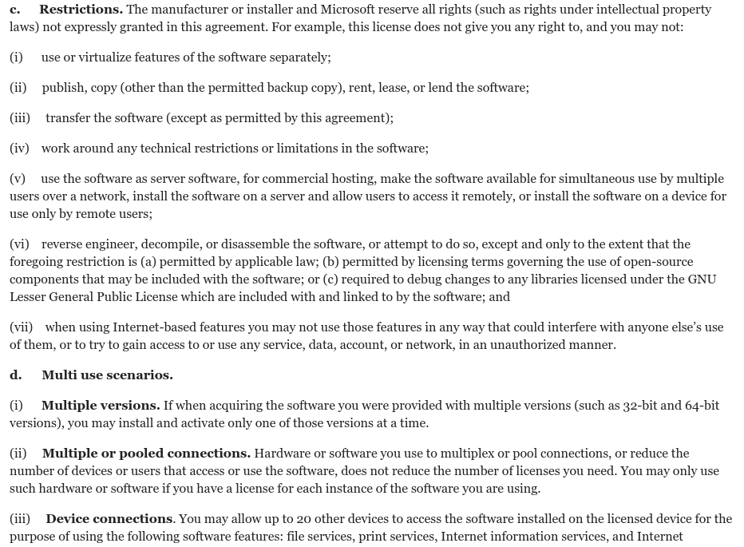

limited warranty (ie no warranty):

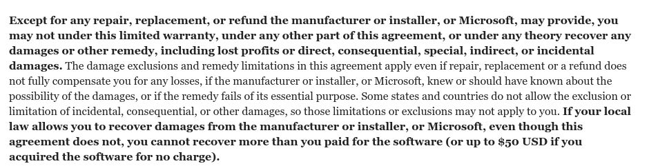

**GNU Public license**:

https://www.gnu.org/licenses/old-licenses/gpl-2.0.html) (https://www.gnu.org/licenses/gpl-3.0.html complicated, incomprehensible legal mumbo-jumbo)

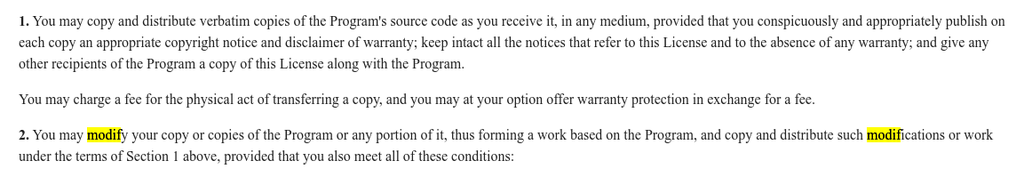

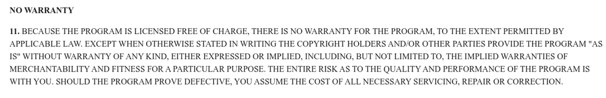

Lawrence Lessig and FCM

https://en.wikipedia.org/wiki/Free-culture_movement

Creative Commons license https://creativecommons.org/

https://en.wikipedia.org/wiki/Free_Culture_(book)

### OSS licenses

Viral vs non-viral (https://en.wikipedia.org/wiki/Viral_license)

Dual licence (economy of scope)

### Economics of OSS

It should not work according to ortodox economy. Free riding problem: https://en.wikipedia.org/wiki/Free-rider_problem (Public goods user do not pay for their use while waiting for the others to pay):

A large part of Open Source creators are unpaid volunteers. Why do they sacrifice their (free) time to produce software? Why should thousands of top-noch programmers contribute freely to the provision of a public good [ Lerner and Tirole (2002) ]

Who can afford to do professional work for nothing? What hobbyist can put 3-man years into programming, finding all bugs, documenting his product and distribute for free? [ William (Bill) Henry Gates III (1976) ]

By allowing inventors to have exclusive use of their intellectual property, the government […] increases the incentives for people to invent useful new products, write books, compose songs and write computer software.

[lack of above mentioned incentives] would reduce or destroy the profit incentives to produce new data, books, performances, or other information because creators would reap no reward from their creative activity.

Samuelson and Nordhaus (1998): Economics

### private investment model vs collective-action innovation model

von Hippel and von Krogh (Open Source Software and the ‘Private-Collective’ Innovation Model: Issues for Organization Science" Organization Science 14, 209-223):

**Private investment**: a return on investment is possible due to the effective protection of intellectual property.

Hippel and von Krogh claims that if costs of sharing/receiving information are low, even very small benefits may result in a decision to engage/participate in production of PG.

Transaction costs of exchange of software via WWW/Internet are almost zero.

https://en.wikipedia.org/wiki/Private-collective_model_of_innovation

### Benefits (aka *motivation factors*)

**Motivation factors** **Internal** (Intrisic) and **external** (extrisic) (the theory of self-determination – Ryan and Deci, 2000). Internal motivation is the satisfaction of a need through a specific activity: **ideological**, **altruism**, **joy of creation** (flow concept introduced by Mihaly Csikszentmihalyi).

internally external (mixed): **reputation**, **reciprocity**, **learning**, **personal use** (market failure no aplication evailable).

**extrisic motivation** is an instrument to achieve a specific result: professional career, remuneration (eg for complementary services).

Theory of signaling (Spence 1973; https://en.wikipedia.org/wiki/Michael_Spence): an employer, who does not have all the information about employees, can use information about education as a signal of high skills, diligence or ambition.

Stronger if 1) the results are more visible (for the recipient) 2) the effort has a greater impact on the result.

**Crowding out** Cash incentives can push (**crowd out**) **internal motivation**: the reward perceived as a form of control **weakens** internal motivation.

Extrisic (external) motivation is a weak stimulus (short term effect); in the long runit results in opportunist behavior (Benabou and Tirole 2003).

### OSS Applications

- Linux (os) https://www.linuxfoundation.org/blog/2017/10/2017-linux-kernel-report-highlights-developers-roles-accelerating-pace-change/ https://www.linuxfoundation.org/resources/publications/state-of-linux-kernel-development-2017/ https://www.linuxfoundation.org/resources/publications/publications/linux-kernel-report-2020/
- Apache WWW server https://en.wikipedia.org/wiki/Apache_HTTP_Server

  https://journals.plos.org/plosone/article?id=10.1371/journal.pone.0152976
- LibreOffice (office suite)

  https://oscollege.com/history-of-libreoffice/
- Mysql (database)

  https://www.datasciencecentral.com/profiles/blogs/history-of-mysql
- R (statistical computations) 20 core developers, https://www.r-project.org/contributors.html

  https://bookdown.org/rdpeng/rprogdatascience/history-and-overview-of-r.html

  https://stackoverflow.blog/2017/10/10/impressive-growth-r/
- Gretl (econometric computations) http://gretl.sourceforge.net/ChangeLog.html
- vlc (multimedia player)

sort of **Crowdsourcing** but more active. Other example: OpenStreetMaps, Wikipedia

Corporate engagement in OSS https://www.freecodecamp.org/news/the-top-contributors-to-github-2017-be98ab854e87/

## Homework

Tim O’Reilly: What’s the Future and Why It’s Up to Us (YTube) https://www.youtube.com/watch?v=s3ha6vHapcI and https://www.oreilly.com/library/view/wtf-whats-the/9780062565723/text/9780062565723_Chapter_13.xhtml#_idParaDest-36

Nicholas Carr: IT doesnet matter (HBR/Carr https://hbr.org/2003/05/it-doesnt-matter)

Nicholas Carr: Is Google Making Us Stupid? https://www.theatlantic.com/magazine/archive/2008/07/is-google-making-us-stupid/306868/

This document https://bookdown.org/rudolf_von_ems/information_technology_overview/